# Categorical data

Ariana Fairbanks

9/6/2018

1.0

### Functions introduced in this module:

`factor`, `data.frame`, `tally`, `geom_bar`, `geom_boxplot`, `facet_grid`

## Introduction

In this module, we’ll learn about categorical data and how to summarize it using tables and graphs.

## Load packages

We load the `mosaic` package and the `MASS` package to work with data on risk factors associated with low birth weight.

```r
library(mosaic)
library(MASS)
```

## Working with factor variables

R uses the term “factor variable” to refer to a categorical variable. Your data set may already come with its variables coded correctly as factor variables, but often they are not. For example, our birth weight data `birthwt` has several categorical variables, but they are all coded numerically. (More specifically, they are all coded as integers.) Observe:

```r
str(birthwt)
```

```
'data.frame':   189 obs. of  10 variables:
 $ low  : int  0 0 0 0 0 0 0 0 0 0 ...
 $ age  : int  19 33 20 21 18 21 22 17 29 26 ...
 $ lwt  : int  182 155 105 108 107 124 118 103 123 113 ...
 $ race : int  2 3 1 1 1 3 1 3 1 1 ...
 $ smoke: int  0 0 1 1 1 0 0 0 1 1 ...
 $ ptl  : int  0 0 0 0 0 0 0 0 0 0 ...
 $ ht   : int  0 0 0 0 0 0 0 0 0 0 ...
 $ ui   : int  1 0 0 1 1 0 0 0 0 0 ...
 $ ftv  : int  0 3 1 2 0 0 1 1 1 0 ...
 $ bwt  : int  2523 2551 2557 2594 2600 2622 2637 2637 2663 2665 ...
```

We are interested in the `race` variable. At the Console, type

?birthwt

and scroll down to read information about how the `race` variable is coded. You’ll see that “1 = white, 2 = black, 3 = other”. (These are obviously not ideal categories for classifying race.)

The code below is somewhat involved and technical. After the code chunk, I’ll explain what each piece does.

```r
race <- factor(birthwt$race,
               levels = c(1, 2, 3),
               labels = c("White", "Black", "Other"))
race_df <- data.frame(race)
```

First of all, because `birthwt` is a dataset defined in the `MASS` package, we don’t want to modify it. Therefore, if we want to change something, we have to assign a new name to the result of any operation. That is why we have `race <-` at the beginning of the code line. The symbol `<-` is taking the result of the command on the right (in this case, the `factor` command) and giving it a new name.

The `factor` command converts `birthwt$race` into a factor variable. The `levels` of the variable are the pre-existing numerical values. The `labels` are the names we actually want to appear in our output.

The letter `c` in `c(1, 2, 3)` and `c("White", "Black", "Other")` is necessary whenever we want to combine more than one thing into a single expression. (In technical terms, the “c” stands for “combine” or “concatenate” and creates a “vector”.)

The last line takes the single vector `race` and turns it into a data frame that we call `race_df`. Many of the commands we will use require that we analyze variables that are sitting inside of data frames. Let’s see how this worked.

```r
race_df
```

| race |
| --- |
| Black |
| Other |
| White |
| White |
| White |
| Other |
| White |
| Other |
| White |
| White |

[output cut: 179 more lines]

You can see that `race_df` is a data frame with one variable (one column). That variable is called `race`.

Another way to look at variables in a data frame is to use the `str` command.

```r
str(race_df)
```

```
'data.frame':   189 obs. of  1 variable:
 $ race: Factor w/ 3 levels "White","Black",..: 2 3 1 1 1 3 1 3 1 1 ...
```

You can see from the output that this created a data frame called `race_df` containing a single factor variable called `race` sitting inside it. The values of race are no longer numbers 1, 2, or 3. Instead, those numbers have been replaced by human-readable words describing the three racial categories.

If a variable is already coded as a factor variable in its data frame, it is important **not** to use the `factor` command on it. This will mess up the data and make all future attempts at analysis break. It is, therefore, extremely important that you check the original data frame first using `str`. **If the variable of interest is already coded as a factor variable, you cannot use the `factor` command.**

## Summarizing one categorical variable

If you need to summarize a single categorical variable, a frequency table usually suffices. We’ll use the `tally` command from the `mosaic` package to create all tables. Don’t worry about the tilde (~) now. You’ll learn about it later.

```r
tally(~ race, data = race_df)
```

```
race
White Black Other
   96    26    67
```

If you want proportions or percentages, you have to add either `format = "proportion"` or `format = "percent"` to the `tally` function.

```r
tally(~ race, data = race_df, format = "proportion")
```

```
race
    White     Black     Other
0.5079365 0.1375661 0.3544974
```

```r
tally(~ race, data = race_df, format = "percent")
```

```
race
   White    Black    Other
50.79365 13.75661 35.44974
```

##### Exercise 1(a)

Generate a frequency table like above, but this time use `data = birthwt` to grab the *unmodified* `race` variable from the original `birthwt` data frame.

```r
# Add code here to create a frequency table of race with data = birthwt.
tally(~ race, data = birthwt, format = "proportion")
```

```
race
        1         2         3
0.5079365 0.1375661 0.3544974
```

##### Exercise 1(b)

Explain the advantage of creating a factor variable with meaningful labels over using the original numerical variable.

It’s easier to read and interpret the labels than the numerical values.

## Graphing one categorical variable

When asked, “What type of graph should I use when graphing a single categorical variable?” the simple answer is “None.” If you do need to summarize a categorical variable, a frequency table usually suffices.

If you really, really want a graph, the standard type is a bar chart. Here is the `ggplot` command to do that:

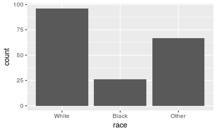

```r
ggplot(race_df, aes(x = race)) +
    geom_bar()
```

As a reminder, the first argument of the `ggplot` command is the name of the data frame, in this case, `race_df`. Next we define the aesthetics using `aes` and parentheses. Inside the parentheses, we assign any variables we want to plot to aesthetics of the graph. For this analysis, we are only interested in the variable `race` and for a bar chart, the categorical variable typically goes on the x-axis. That’s why it says `x = race` inside the `aes` argument. Next, `ggplot` needs to know what kind of graph we want. Adding `geom_bar()` tells `ggplot` to add a bar chart layer.

This can be modified somewhat to give proportions (relative frequencies) on the y-axis instead of counts. Unfortunately, the `ggplot` syntax is not very transparent here. My recommendation is to copy and paste the code below if you need to make a relative frequency bar chart in the future, making the necessary changes to the data frame and variable, of course.

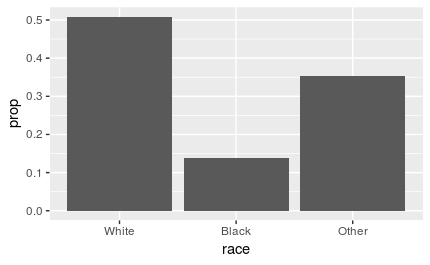

```r
ggplot(race_df, aes(x = race, y = ..prop.., group = 1)) +
    geom_bar()
```

These bar charts are the graphical analogues of a frequency table and a relative frequency table, respectively.

##### Exercise 2

In a sentence or two at most, describe the distribution of race in this data set.

About 50% of the women are white, ~15% are black, and ~35% belong to another nationality.

What about pie charts? Just. Don’t.

Seriously. Pie charts suck.[^1]

## Summarizing two categorical variables

A table summarizing two categorical variables is called a contingency table (or pivot chart, or cross-tabulation, or probably several other terms as well).

For example, we might pose the following research question: is smoking during pregnancy associated with a woman’s race?

First things first, though. We need to create one more factor variable. We’ll use the `smoke` variable about whether the mothers smoked during pregnancy.

```r
smoke <- factor(birthwt$smoke,
                levels = c(1, 0),
                labels = c("Yes", "No"))
smoke_race <- data.frame(smoke, race)
```

The `smoke` variable is created in exactly the same way as the `race` variable was earlier. Now, though, because we want to analyze both `smoke` and `race` together, we create a new data frame called `smoke_race` with both variables.

When we work with two variables, typically we think of one variable as response and the other as explanatory. For reasons that will become more clear later, we will adopt the convention of always listing the response variable first, followed by the explanatory variable. So we use `smoke_race` instead of `race_smoke`.

Let’s make sure the above commands did what we intended.

```r
smoke_race
```

| smoke | race |
| --- | --- |
| No | Black |
| No | Other |
| Yes | White |
| Yes | White |
| Yes | White |
| No | Other |
| No | White |
| No | Other |
| Yes | White |
| Yes | White |

[output cut: 179 more lines]

We check `str` as well.

```r
str(smoke_race)
```

```
'data.frame':   189 obs. of  2 variables:
 $ smoke: Factor w/ 2 levels "Yes","No": 2 2 1 1 1 2 2 2 1 1 ...
 $ race : Factor w/ 3 levels "White","Black",..: 2 3 1 1 1 3 1 3 1 1 ...
```

Examine the output from the above code to make sure we have a data frame with the two factor variables we want.

You may be wondering why the command looked like this:

`smoke <- factor(birthwt$smoke, levels = c(1, 0), labels = c("Yes", "No"))`

instead of like this:

`smoke <- factor(birthwt$smoke, levels = c(0, 1), labels = c("No", "Yes"))`.

For most response variables, we often designate one category as a category of interest in our study. This category is often called the “Success” condition. For example, the question we’re asking about this data is, “Within each racial category, what percentage of mothers smoked?” Therefore, the “Yes” condition in the `smoke` variable is considered the “Success” category (even though there’s obviously nothing “successful” about smoking while pregnant!). When we list that success category first in the factor command, R will treat it a little differently than other categories. It’s not so important to us here, but it will be very important in the future. This typically only matters for the response variable. (The explanatory variable is `race` and we’re not singling out one racial category as being of more interest to us than any other.)

The `tally` command uses R’s “formula” notation to indicate which variable is response and which value is explanatory. The response variable goes first, followed by a tilde (~), followed by the explanatory variable:

`response ~ explanatory`

In other words, we are using knowledge of a woman’s race to *predict* if she is a smoker. Therefore, `smoke` is response and `race` is explanatory. In the `tally` command, we’ll need to use the formula

`smoke ~ race`.

And now for the contingency table. The `tally` command will, by default, put the response variable in the rows and the explanatory variable in the columns. We’ll also add a new argument `margins = TRUE` to print the marginal distribution (the column totals).

```r
tally(smoke ~ race, data = smoke_race, margins = TRUE)
```

```
       race
smoke   White Black Other
  Yes      52    10    12
  No       44    16    55
  Total    96    26    67
```

Unfortunately, this table is highly misleading. For example, one cannot compare the 10 black women who smoked to the 12 “other” women who smoked. The 10 are out of 26, but the 12 are out of 67. That’s why we need percentages.

```r
tally(smoke ~ race, data = smoke_race, margins = TRUE, format = "percent")
```

```
       race
smoke       White     Black     Other
  Yes    54.16667  38.46154  17.91045
  No     45.83333  61.53846  82.08955
  Total 100.00000 100.00000 100.00000
```

Now we can see that each column adds up to 100%. In other words, each racial group is now on equal footing, and only the distribution of smokers within each group matters.

##### Exercise 3(a)

What percentage of black women smoked during pregnancy? What percentage of “other” women smoked during pregnancy?

38.5% of black women and 17.9% of ‘other’ women smoked during their pregnancy.

##### Exercise 3(b)

Does the likelihood of smoking during pregnancy appear to be associated with race for the women in this data set? Or are these variables independent?

According to the data, the percentage of women who smoked during their pregnancy varied significantly between the races. This implies that there may be some connection between the two.

##### Exercise 4

Choose two categorical variables of interest from the `birthwt` data set. Identify one as response and one as explanatory. (Choose at least one variable other than `race` or `smoke`.) Turn them into factor variables with meaningful labels. (If you use `race` or `smoke` again, **do not** use factor again!) Create a new data frame containing both variables. Then create a contingency table with percentages. Comment on the association (or independence) of the two variables.

```r
lwgt <- factor(birthwt$low,
                levels = c(1, 0),
                labels = c("Yes", "No"))
wgtSmk <- data.frame(lwgt, smoke)
#wgtSmk
```

```r
tally(lwgt ~ smoke, data = wgtSmk, margins = TRUE, format = "percent")
```

```
       smoke
lwgt          Yes        No
  Yes    40.54054  25.21739
  No     59.45946  74.78261
  Total 100.00000 100.00000
```

40.5% of women who smoked gave birth to a child with a low birth weight, compared to only 25.2% of women who didn’t. This indicates that there is likely some association between smoking during a pregnancy and the likelyhood of a low birth weight.

## Graphing two categorical variables

A somewhat effective way to display two categorical variables is with a side-by-side bar chart. Here is the `ggplot` code:

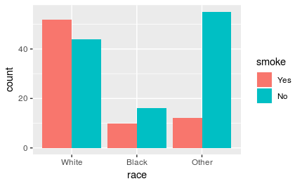

```r
ggplot(smoke_race, aes(fill = smoke, x = race)) +
    geom_bar(position = "dodge")
```

This is somewhat different from other `ggplot` examples you’ve seen before, so let’s take a moment to go through it. The first argument is the data frame `smoke_race`; no mystery there. The second aesthetic `x = race` also makes a lot of sense. As `race` is our explanatory variable—we’re using race to group the women, and then within each racial group, we’re interested in how many women smoked during pregnancy—`race` goes on the x-axis. However, `smoke` does not go on the y-axis! (This is a very common mistake for novices.) The y-axis of a bar chart is always a count or a percentage, so no variable should ever go on the y-axis of a bar chart. In that case, how does `smoke` enter the picture? Through the use of color! The aesthetic `fill = smoke` says to use the `smoke` variable to shade or “fill” the bars with different colors. You’ll also notice that `ggplot` makes a legend automatically with the colors so you can see which color corresponds to which value (in this case, “Yes” or “No”).

Another unusual feature is the argument `position = "dodge"` in the `geom_bar` layer. Let’s see what happens if we remove it.

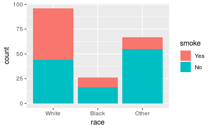

```r
ggplot(smoke_race, aes(fill = smoke, x = race)) +
    geom_bar()
```

We get a stacked bar chart! This is another popular way of displaying two categorical variables, but I don’t tend to prefer it. Notice how difficult it is to compare the number of smokers across races; since there is no common baseline for the red segments of each bar, it is harder to determine which ones are bigger or smaller. (In this case, it’s obvious for the “White” group, but not so obvious between “Black” and “Other”.)

So let’s agree to use side-by-side bar charts. There is still one aspect of the side-by-side bar chart that is misleading, though. For example, there are 10 black women who smoked during pregnancy and 12 women from the “Other” category who smoked during pregnancy. So are women from the “Other” category more likely to smoke during pregnancy? No! The 10 black women are only out of 26 total black women, whereas the 12 other women are out of a total of 67. That’s really 38.5% of black women compared to 17.9% other women.

To fix this problem, a better option here would be to use relative frequencies (i.e., percentages within each group) instead of counts on the y-axis. (This is analogous to using percentages in a contingency table.) Unfortunately, it is rather difficult to do this with `ggplot`. A compromise is available: by using `position = fill`, you can create a stacked bar chart that scales every group to 100%. Making comparisons across groups can still be hard, as explained above for any kind of stacked bar chart, but it works okay if there are only two categories in the response variable (as is the case with `smoke` here).

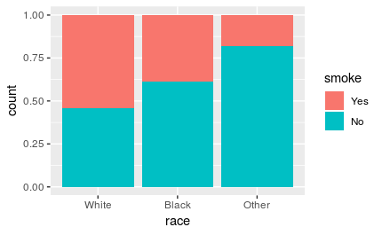

```r
ggplot(smoke_race, aes(fill = smoke, x = race)) +
    geom_bar(position = "fill")
```

This graph does correctly show that a larger proportion of black women in this sample smoked during pregnancy when compared to women from the “Other” category. (And white women smoked the most of all; the majority of white women smoked during pregnancy in this data set!)

##### Exercise 5

Use the same two categorical variables from Exercise 4. (They should already be defined and placed in their own data frame.) Create a side-by-side bar chart. Comment on the association (or independence) of the two variables.

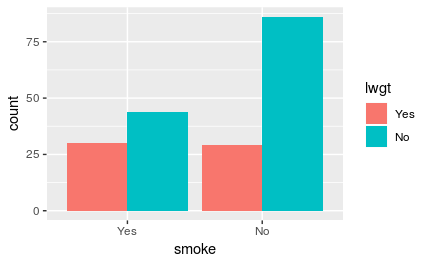

```r
ggplot(wgtSmk, aes(fill = lwgt, x = smoke)) +
    geom_bar(position = "dodge")
```

The display is different, but my answer is still the same. There is significant difference in the percentage of low birth weights when the mother smoked compared to when she didn’t, which is indicates that those variables are likely correlated.

## Graphing grouped numerical data

Suppose you want to analyze one numerical variable and one categorical variable. Usually, the idea here is that the categorical variable divides up the data into groups and you are interested in understanding the numerical variable for each group separately. Another way to say this is that your numerical variable is response and your categorical variable is explanatory. (It is also possible for a categorical variable to be response and a numerical variable to be explanatory. This is common in so-called “classification” problems. We will not cover this possibility in this course, but it is covered in more advanced courses.)

For an example, let’s consider the mother’s weight by race. As always, we’ll need to make a data frame that contains both variables `race` and `lwt` together. In the following code, note that `race` can be included in the data frame as is, but `birthwt$lwt` has to be renamed as `lwt`. This is because there is already a variable called `race` defined in the Global Environment. (We created it earlier by converting the variable `birthwt$race` to a factor variable.) But there is no variable in the Global Environment called `lwt`. Of course, we don’t need to *convert* `birthwt$lwt` because it’s already coded numerically (in this case as `int`, meaning an integer, or whole number). But we do need to rename the variable so it enters the new data frame with the concise name `lwt`.

```r
lwt_race <- data.frame(lwt = birthwt$lwt, race)
```

We check to make sure this worked.

```r
lwt_race
```

| lwt | race |
| --- | --- |
| 182 | Black |
| 155 | Other |
| 105 | White |
| 108 | White |
| 107 | White |
| 124 | Other |
| 118 | White |
| 103 | Other |
| 123 | White |
| 113 | White |

[output cut: 179 more lines]

```r
str(lwt_race)
```

```
'data.frame':   189 obs. of  2 variables:
 $ lwt : int  182 155 105 108 107 124 118 103 123 113 ...
 $ race: Factor w/ 3 levels "White","Black",..: 2 3 1 1 1 3 1 3 1 1 ...
```

Indeed, we see in the output that there are two variables, one numerical (`lwt`), and one categorical (the factor variable `race`).

Graphically, there are two good options here. The first is a side-by-side boxplot.

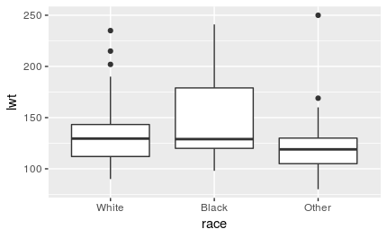

```r
ggplot(lwt_race, aes(y =lwt, x = race)) +
    geom_boxplot()
```

Notice the placement of the variables. The y-axis is `lwt`, the numerical variable. The x-axis variable is `race`; the groups are placed along the x-axis. This is consistent with other graph types that place the response variable on the y-axis and the explanatory variable on the x-axis.

The other possible graph is a stacked histogram. This uses a feature called “faceting” that creates a different plot for each group. The syntax is a little unusual.

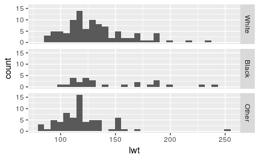

```r
ggplot(lwt_race, aes(x = lwt)) +
    geom_histogram() +
    facet_grid(race ~ .)
```

The argument `race ~ .` in the `facet_grid` function means, “Put each race on a different row.” We’ll explore this notation a little later.

As always, the default bins suck, so let’s change them.

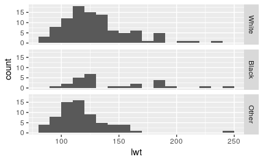

```r
ggplot(lwt_race, aes(x = lwt)) +
    geom_histogram(binwidth = 10, boundary = 100) +
    facet_grid(race ~ .)
```

Consider the following subtle change in notation:

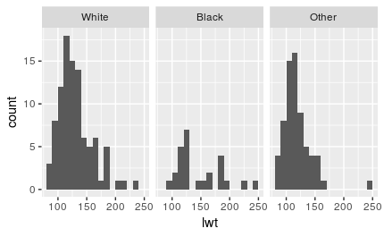

```r
ggplot(lwt_race, aes(x = lwt)) +
    geom_histogram(binwidth = 10, boundary = 100) +
    facet_grid(. ~ race)
```

##### Exercise 6

Explain why that last graph (which might be called a side-by-side histogram) is less effective than the earlier stacked histogram. (Hint: what stays lined up when the histograms are stacked vertically rather than horizontally?) Also, can you figure out what’s going on with the weird syntax of `race ~ .` vs `. ~ race`? Explain it in your own words.

It’s easier to compare how the data is spread out in each graph when they are stacked vertically.

The syntax seems to determine if the histograms will be side by side or stacked on top of each other.

The other thing that kind of sucks is the fact that the y-axis is showing counts. That makes it hard to see the distribution of weight among black women, for example, as there are fewer of them in the data set. It would be nice to scale these using percentages.

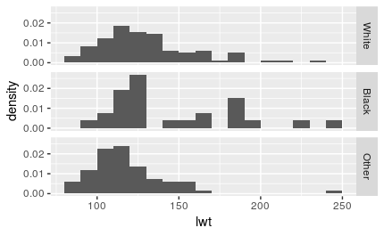

```r
ggplot(lwt_race, aes(x = lwt)) +
    geom_histogram(aes(y = ..density..), binwidth = 10, boundary = 100) +
    facet_grid(race ~ .)
```

Due to some technical issues in `ggplot2`, these are not strictly proportions. (If you were to add up the heights of all the bars, they would not add up to 100%.) Nevertheless, the graph is still useful because it does scale the groups to put them on equal footing. In other words, it treats each group as if they all had the same sample size.

##### Exercise 7

Choose an interesting numerical variable and an interesting categorical variable from the `birthwt` data set. (Choose at least one variable you haven’t used already.) Convert the categorical variable to a factor variable if it hasn’t already been done earlier. Create a data frame with your chosen variables. Then make both a side-by-side boxplot and a stacked histogram. Discuss the resulting graphs. Comment on the association (or independence) of the two variables.

```r
ptlrace <- data.frame(ptl = birthwt$ptl, race)
```

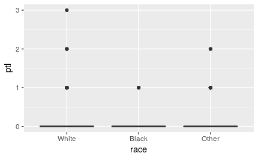

```r
ggplot(ptlrace, aes(y = ptl, x = race)) +
    geom_boxplot()
```

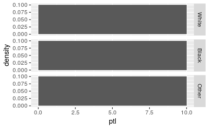

```r
ggplot(ptlrace, aes(x = ptl)) +
    geom_histogram(aes(y = ..density..), binwidth = 10, boundary = 10) +
    facet_grid(race ~ .)
```

Maybe I should have chosen a different variable to get better graphs, but I’ve already done it.

The data shows that, regardless of race, most women have had no prior premature births. There doesn’t seem to be any correlation between the two variables.

## Publication-ready graphics

Let’s go back to the first relative frequency bar chart from this module.

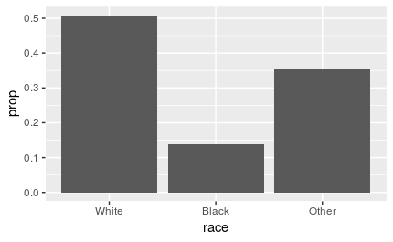

```r
ggplot(race_df, aes(x = race, y = ..prop.., group = 1)) +
    geom_bar()
```

The variable name `race` is already informative, but the y-axis is labeled with “prop”. Also note that this graph could use a title. We can do all this with `labs` (for labels). Observe:

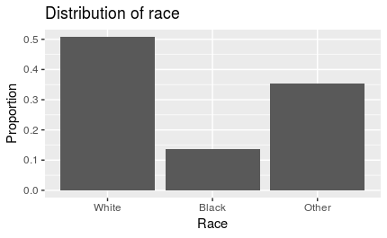

```r
ggplot(race_df, aes(x = race, y = ..prop.., group = 1)) +
    geom_bar() +
    labs(title = "Distribution of race",
         y = "Proportion",
         x = "Race")
```

Here’s the side-by-side boxplot from earlier in the module, but this time with title and axis labels.

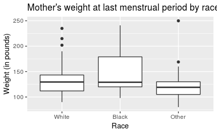

```r
ggplot(lwt_race, aes(y =lwt, x = race)) +
    geom_boxplot() +
    labs(title = "Mother's weight at last menstrual period by race",
         y = "Weight (in pounds)",
         x = "Race")
```

You can also see that we took the opportunity to mention the units of measurement (pounds) for our numerical variable in the y-axis label. This is good practice.

##### Exercise 8

Modify the following side-by-side bar chart by adding a title and labels for both the fill variable and the x-axis variable.

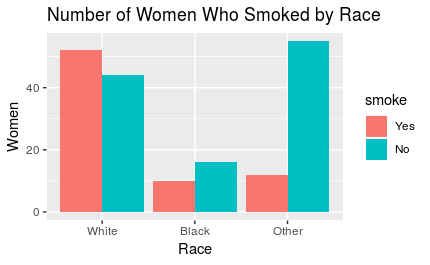

```r
ggplot(smoke_race, aes(fill = smoke, x = race)) +
    geom_bar(position = "dodge") +
    labs(title = "Number of Women Who Smoked by Race",
         y = "Women",
         x = "Race")
```

##### Exercise 9

Modify the following stacked histogram by adding a title and labels for both the y-axis and x-axis.

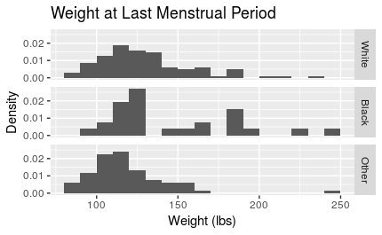

```r
ggplot(lwt_race, aes(x = lwt)) +
    geom_histogram(aes(y = ..density..), binwidth = 10, boundary = 100) +
    facet_grid(race ~ .) +
    labs(title = "Weight at Last Menstrual Period",
         y = "Density",
         x = "Weight (lbs)")
```

## Conclusion

You can summarize a single categorical variable using a frequency table. For only one categorical variable, a graph is usually overkill, but if you really want a graph, the bar chart is the best option. Both raw counts and percentages can be useful.

We use contingency tables to summarize two categorical variables. Unless groups are of equal size, raw counts can be incredibly misleading here. You should include percentages to be able to compare the distributions across groups. If the percentages are roughly the same, the variables are more likely to be independent, whereas if the percentages are different, there may be an association between the variables. For graphing, the best choice is usually a side-by-side bar chart. A stacked bar chart will also work, especially if using relative frequencies on the y-axis, but it can be hard to compare across groups when the response variable has three or more categories.

When you want to analyze a numerical response variable using an explanatory categorical variable as a grouping variable, there are two good options: the side-by-side boxplot and the stacked histogram.

[^1]: https://medium.com/the-mission/to-pie-charts-3b1f57bcb34a